# Projeto - Red Wine Analisys

Eleandro Angelo Biondo

23 de julho de 2019

# Projeto - Red Wine Analisys

Foi escolhido o data set de vinhos tintos para analise pelo interesse que o tema desperta. Sempre se busca atraves da analise dos elementos quimicos traĂ§ar uma correlacao entre sua presenĂ§a quantitativa e a qualidade do vinho.

Neste conjunto de dados foram analisados 1599 vinhos tintos e avaliados pela sua qualidade sensorial em notas que variam de 1 ate 10.

Como e natural, o enfoque da analise levara em conta a qualidade, que no fim das contas e o que determina o preĂ§o e a demanda do produto.

# Primeira visao do dados

```
## [1] "C:/Users/Eleandro/Documents/AnĂĄlise de Dados/RedWine"
```

```
##   fixed.acidity volatile.acidity citric.acid residual.sugar chlorides
## 1           7.4             0.70        0.00            1.9     0.076
## 2           7.8             0.88        0.00            2.6     0.098
## 3           7.8             0.76        0.04            2.3     0.092
## 4          11.2             0.28        0.56            1.9     0.075
## 5           7.4             0.70        0.00            1.9     0.076
## 6           7.4             0.66        0.00            1.8     0.075
##   free.sulfur.dioxide total.sulfur.dioxide density   pH sulphates alcohol
## 1                  11                   34  0.9978 3.51      0.56     9.4
## 2                  25                   67  0.9968 3.20      0.68     9.8
## 3                  15                   54  0.9970 3.26      0.65     9.8
## 4                  17                   60  0.9980 3.16      0.58     9.8
## 5                  11                   34  0.9978 3.51      0.56     9.4
## 6                  13                   40  0.9978 3.51      0.56     9.4
##   quality
## 1       5
## 2       5
## 3       5
## 4       6
## 5       5
## 6       5
```

```r
summary(redWines)
```

```
##  fixed.acidity   volatile.acidity  citric.acid    residual.sugar
##  Min.   : 4.60   Min.   :0.1200   Min.   :0.000   Min.   : 0.900
##  1st Qu.: 7.10   1st Qu.:0.3900   1st Qu.:0.090   1st Qu.: 1.900
##  Median : 7.90   Median :0.5200   Median :0.260   Median : 2.200
##  Mean   : 8.32   Mean   :0.5278   Mean   :0.271   Mean   : 2.539
##  3rd Qu.: 9.20   3rd Qu.:0.6400   3rd Qu.:0.420   3rd Qu.: 2.600
##  Max.   :15.90   Max.   :1.5800   Max.   :1.000   Max.   :15.500
##    chlorides       free.sulfur.dioxide total.sulfur.dioxide
##  Min.   :0.01200   Min.   : 1.00       Min.   :  6.00
##  1st Qu.:0.07000   1st Qu.: 7.00       1st Qu.: 22.00
##  Median :0.07900   Median :14.00       Median : 38.00
##  Mean   :0.08747   Mean   :15.87       Mean   : 46.47
##  3rd Qu.:0.09000   3rd Qu.:21.00       3rd Qu.: 62.00
##  Max.   :0.61100   Max.   :72.00       Max.   :289.00
##     density             pH          sulphates         alcohol
##  Min.   :0.9901   Min.   :2.740   Min.   :0.3300   Min.   : 8.40
##  1st Qu.:0.9956   1st Qu.:3.210   1st Qu.:0.5500   1st Qu.: 9.50
##  Median :0.9968   Median :3.310   Median :0.6200   Median :10.20
##  Mean   :0.9967   Mean   :3.311   Mean   :0.6581   Mean   :10.42
##  3rd Qu.:0.9978   3rd Qu.:3.400   3rd Qu.:0.7300   3rd Qu.:11.10
##  Max.   :1.0037   Max.   :4.010   Max.   :2.0000   Max.   :14.90
##     quality
##  Min.   :3.000
##  1st Qu.:5.000
##  Median :6.000
##  Mean   :5.636
##  3rd Qu.:6.000
##  Max.   :8.000
```

```r
str(redWines)
```

```
## 'data.frame':    1599 obs. of  12 variables:
##  $ fixed.acidity       : num  7.4 7.8 7.8 11.2 7.4 7.4 7.9 7.3 7.8 7.5 ...
##  $ volatile.acidity    : num  0.7 0.88 0.76 0.28 0.7 0.66 0.6 0.65 0.58 0.5 ...
##  $ citric.acid         : num  0 0 0.04 0.56 0 0 0.06 0 0.02 0.36 ...
##  $ residual.sugar      : num  1.9 2.6 2.3 1.9 1.9 1.8 1.6 1.2 2 6.1 ...
##  $ chlorides           : num  0.076 0.098 0.092 0.075 0.076 0.075 0.069 0.065 0.073 0.071 ...
##  $ free.sulfur.dioxide : num  11 25 15 17 11 13 15 15 9 17 ...
##  $ total.sulfur.dioxide: num  34 67 54 60 34 40 59 21 18 102 ...
##  $ density             : num  0.998 0.997 0.997 0.998 0.998 ...
##  $ pH                  : num  3.51 3.2 3.26 3.16 3.51 3.51 3.3 3.39 3.36 3.35 ...
##  $ sulphates           : num  0.56 0.68 0.65 0.58 0.56 0.56 0.46 0.47 0.57 0.8 ...
##  $ alcohol             : num  9.4 9.8 9.8 9.8 9.4 9.4 9.4 10 9.5 10.5 ...
##  $ quality             : int  5 5 5 6 5 5 5 7 7 5 ...
```

# Sessao de graficos com dados univariados

Visao dos dados atraves de histogramas.

Com tantas variaveis, inicialmente, seria adequado que fosse feita a visualizacao da distribuicao dos vinhos observados por qualidade e entao por cada uma das demais variaveis, de forma a se ter uma ideia da existencia de simetria na distribuicoes observavel pelo histograma.

Em alguns histogramas foram aplicadas limitacoes nos eixos X e Y de modo a excluir os outliers, assim como no histograma de dioxido de enxofre foi aplicada a camada da escala logaritmica no eixo X.

Os histogramas com base nos dados do modo como se encontram, de modo geral, nao permitem concluir que qualquer das variaveis segue a mesma distribuicao aplicavel a qualidade, sendo, portanto, recomendavel o tratamento dos dados.

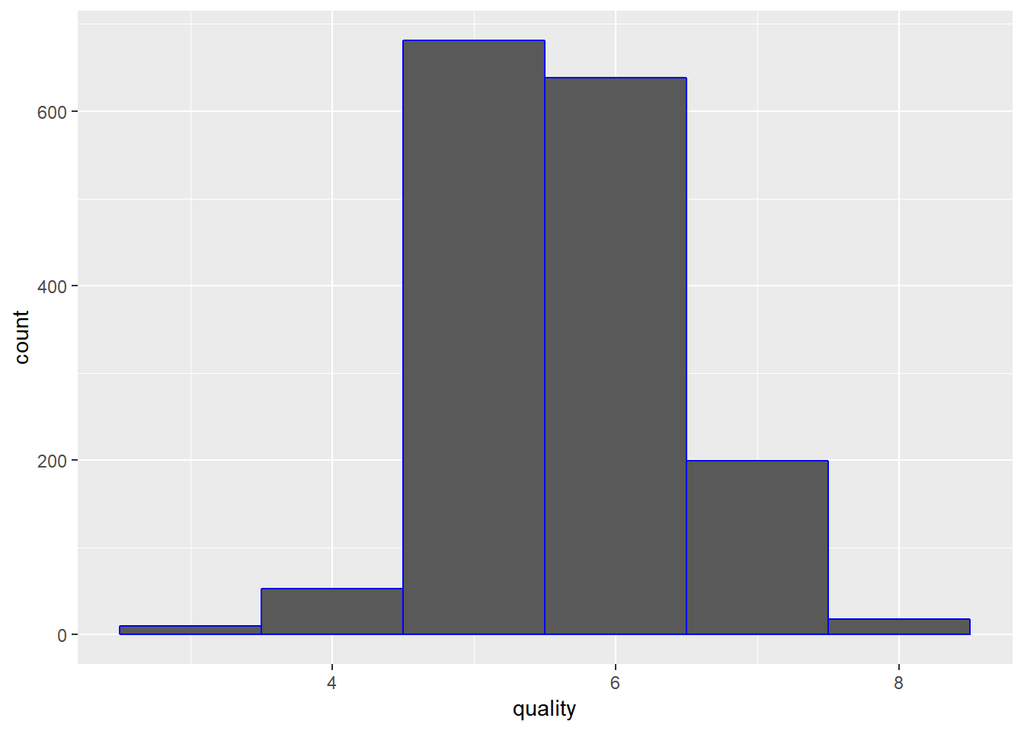

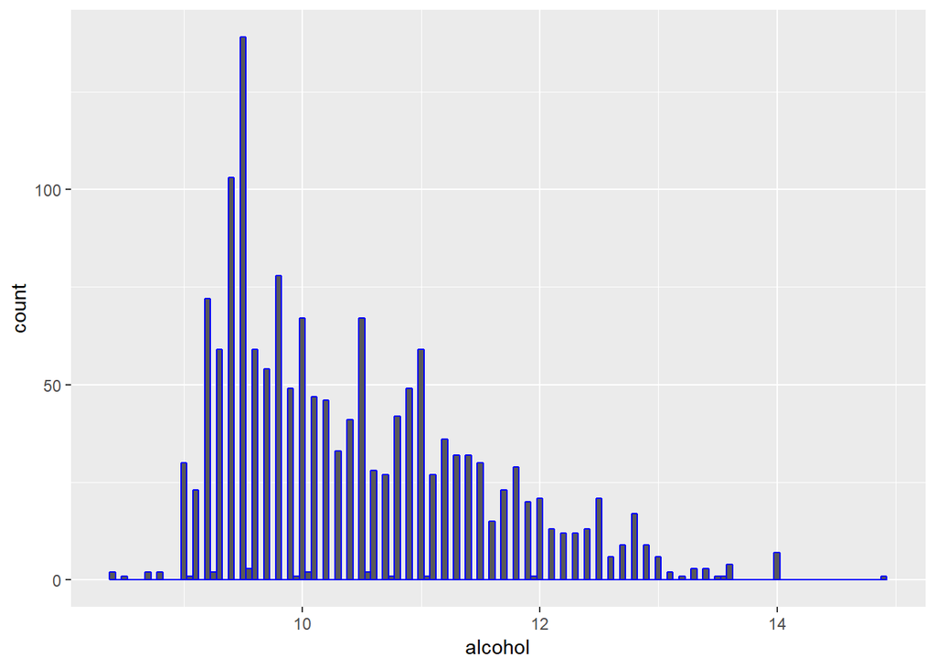

Histograma do pH limitado no eixo X para excluir excluir os outliers.

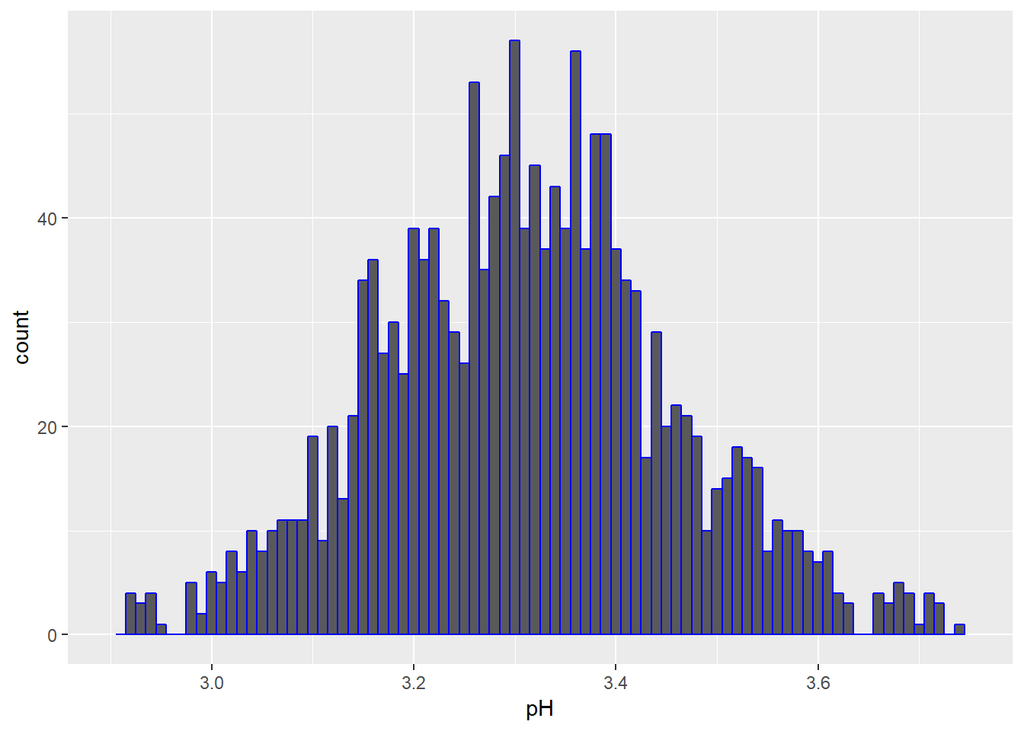

Histograma dos sulfatos ajustado no eixo X para excluir os outliers.

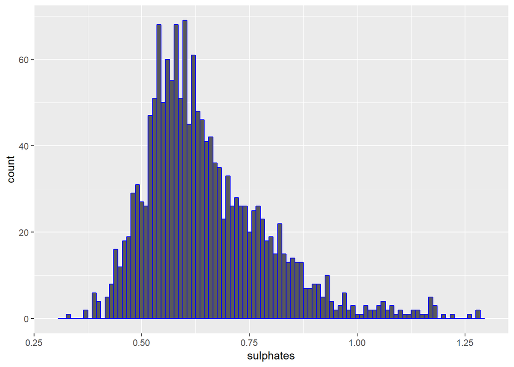

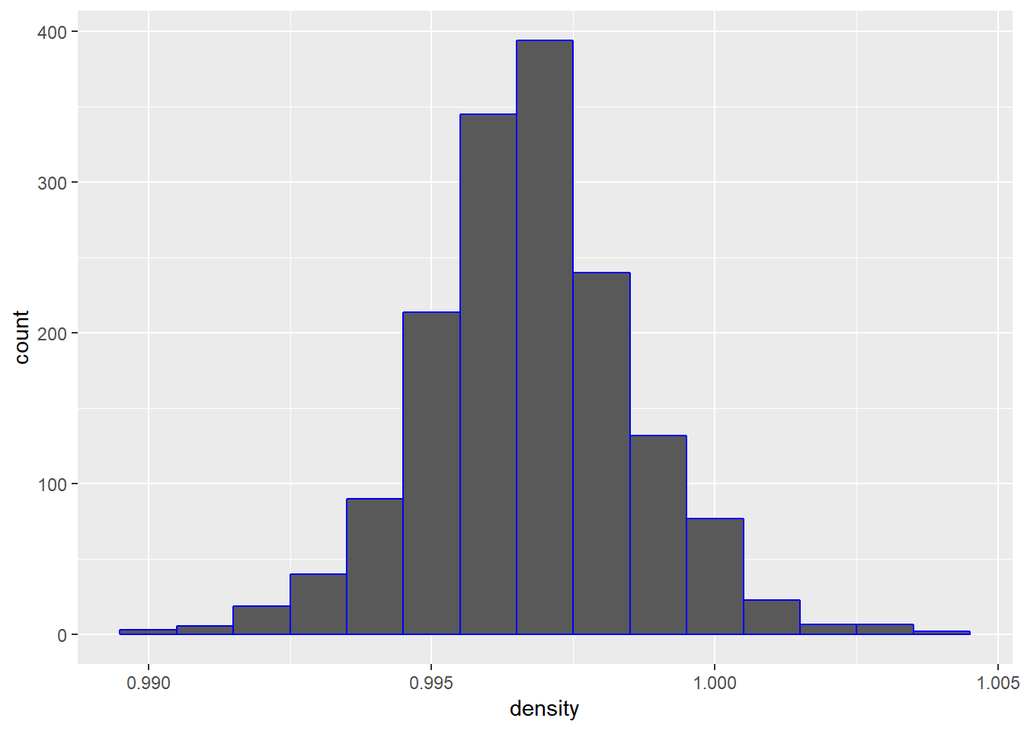

Histograma do dioxido de enxofre ajustado no ĂŞxito X para excluir os outliers.

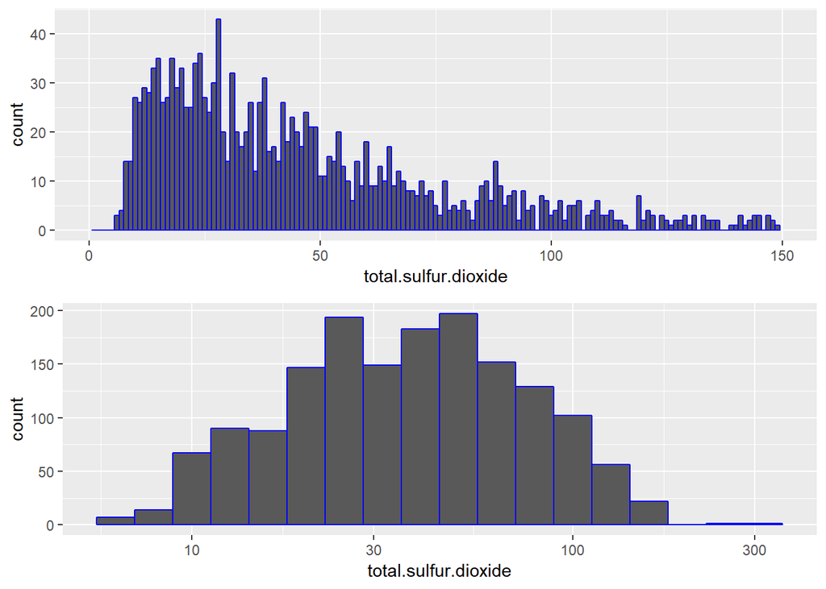

Histograma do diĂłxido de enxofre livre limitado nos eixo X e Y para excluir os outliers.

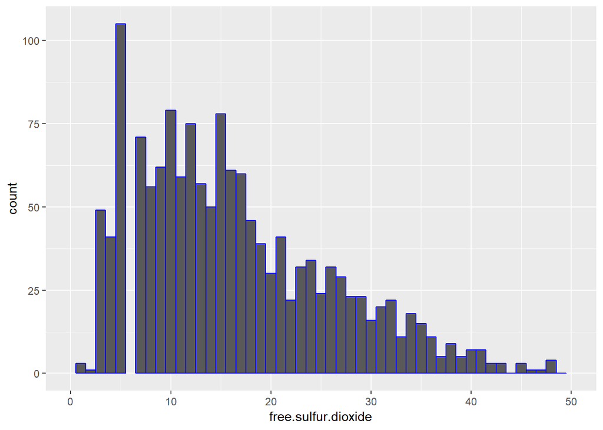

Histograma dos cloretos limitado no eixo X para excluir os outliers.

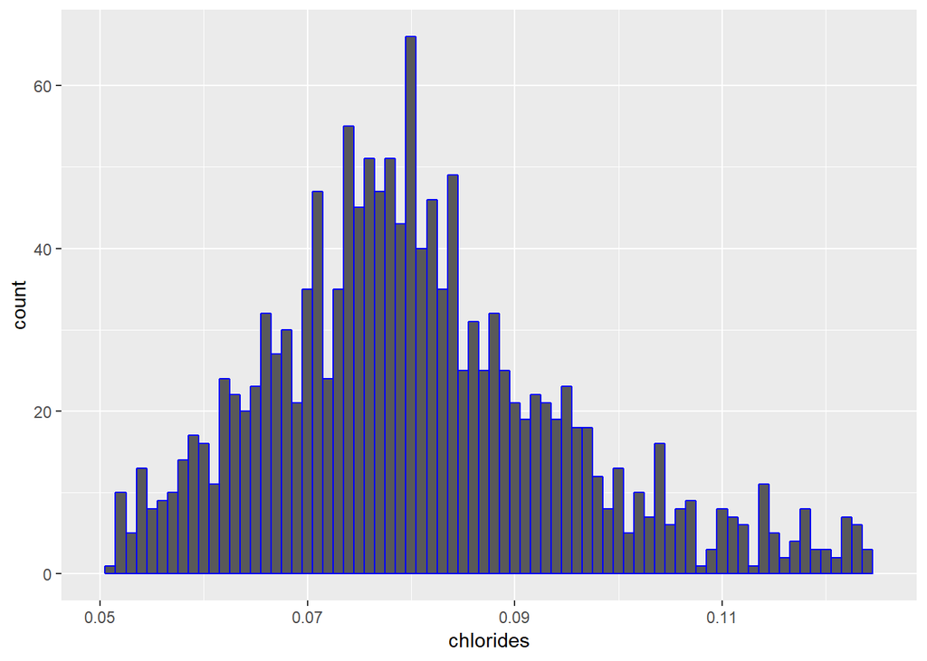

Histograma do acucar residual ajustado no eixo X para excluir os outliers.

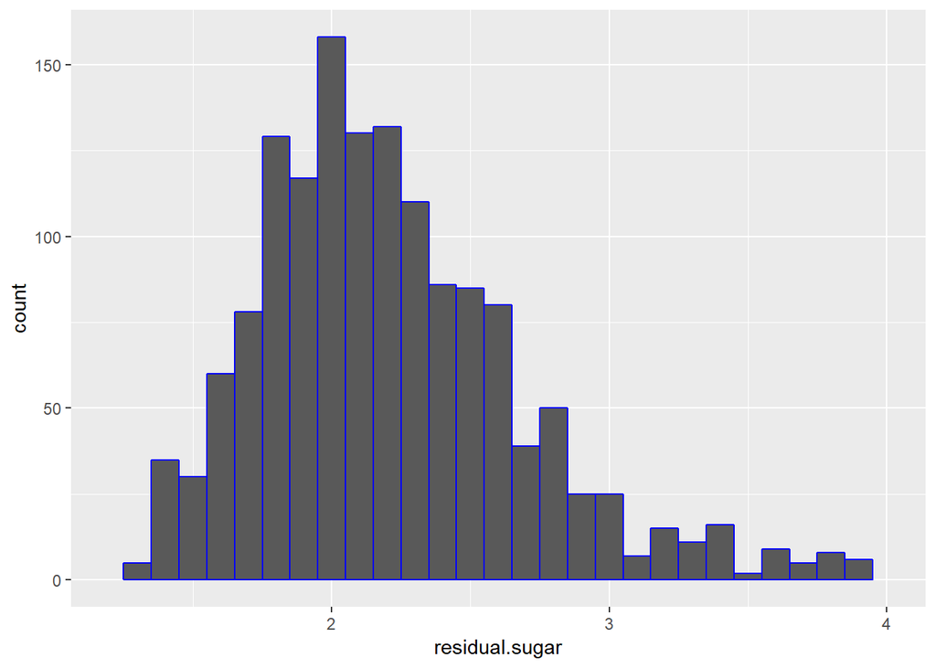

Histograma do acido citrico ajustado nos eixos X e Y para excluir os outliers.

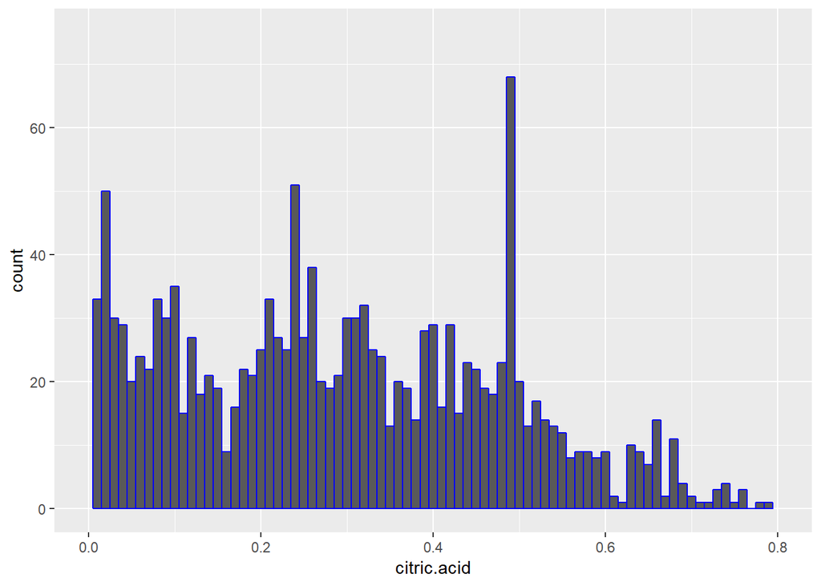

Histograma da acidez volatil ajustada no eixo X para excluir os outliers.

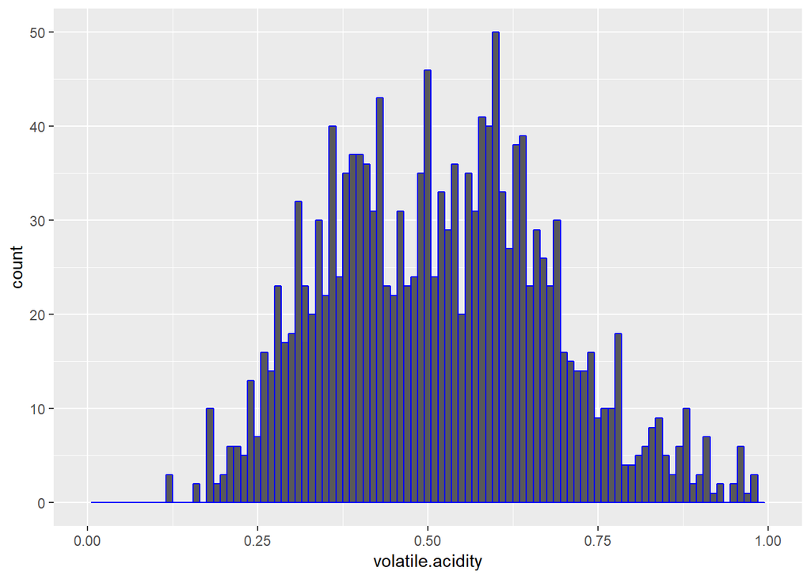

Histograma da acidez fixada ajustada no eixo X para excluir os outliers.

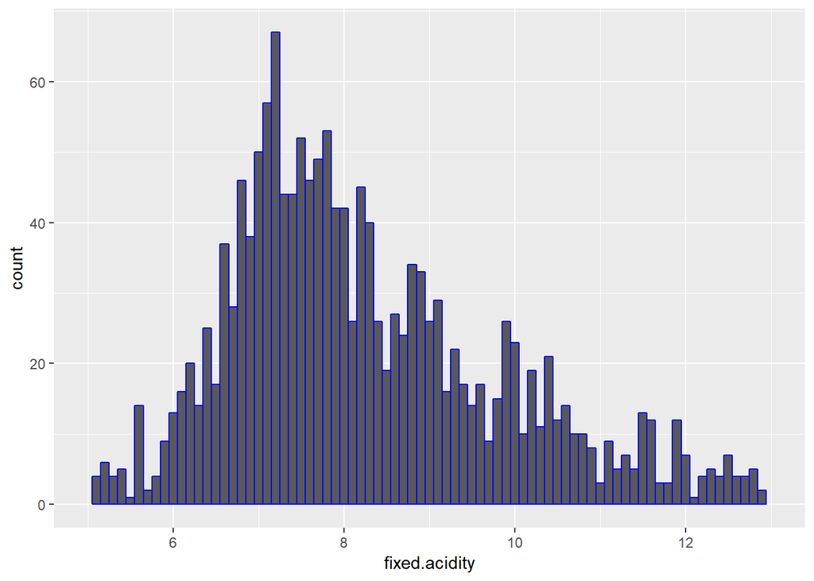

# Correlacao

Os graficos de correlacao vao demonstrar com base nos dados brutos a existencia de tendĂŞncia entre o acrescimo ou decrescimo da qualidade e a presenca maior ou menor de variaveis no vinho.

```
##
##  Pearson's product-moment correlation
##
## data:  redWines$quality and redWines$pH
## t = -2.3109, df = 1597, p-value = 0.02096
## alternative hypothesis: true correlation is not equal to 0
## 95 percent confidence interval:
##  -0.106451268 -0.008734972
## sample estimates:
##         cor
## -0.05773139
```

```
##
##  Pearson's product-moment correlation
##
## data:  redWines$quality and redWines$alcohol
## t = 21.639, df = 1597, p-value < 2.2e-16
## alternative hypothesis: true correlation is not equal to 0
## 95 percent confidence interval:
##  0.4373540 0.5132081
## sample estimates:
##       cor
## 0.4761663
```

```
##
##  Pearson's product-moment correlation
##
## data:  redWines$quality and redWines$chlorides
## t = -5.1948, df = 1597, p-value = 2.313e-07
## alternative hypothesis: true correlation is not equal to 0
## 95 percent confidence interval:
##  -0.17681041 -0.08039344
## sample estimates:
##        cor
## -0.1289066
```

```
##
##  Pearson's product-moment correlation
##
## data:  redWines$quality and redWines$fixed.acidity
## t = 4.996, df = 1597, p-value = 6.496e-07
## alternative hypothesis: true correlation is not equal to 0
## 95 percent confidence interval:
##  0.07548957 0.17202667
## sample estimates:
##       cor
## 0.1240516
```

```
##
##  Pearson's product-moment correlation
##
## data:  redWines$quality and redWines$volatile.acidity
## t = -16.954, df = 1597, p-value < 2.2e-16
## alternative hypothesis: true correlation is not equal to 0
## 95 percent confidence interval:
##  -0.4313210 -0.3482032
## sample estimates:
##        cor
## -0.3905578
```

```
##
##  Pearson's product-moment correlation
##
## data:  redWines$quality and redWines$citric.acid
## t = 9.2875, df = 1597, p-value < 2.2e-16
## alternative hypothesis: true correlation is not equal to 0
## 95 percent confidence interval:
##  0.1793415 0.2723711
## sample estimates:
##       cor
## 0.2263725
```

```
##
##  Pearson's product-moment correlation
##
## data:  redWines$quality and redWines$residual.sugar
## t = 0.5488, df = 1597, p-value = 0.5832
## alternative hypothesis: true correlation is not equal to 0
## 95 percent confidence interval:
##  -0.03531327  0.06271056
## sample estimates:
##        cor
## 0.01373164
```

```
##
##  Pearson's product-moment correlation
##
## data:  redWines$quality and redWines$free.sulfur.dioxide
## t = -2.0269, df = 1597, p-value = 0.04283
## alternative hypothesis: true correlation is not equal to 0
## 95 percent confidence interval:
##  -0.099430290 -0.001638987
## sample estimates:
##         cor
## -0.05065606
```

```
##
##  Pearson's product-moment correlation
##
## data:  redWines$quality and redWines$total.sulfur.dioxide
## t = -7.5271, df = 1597, p-value = 8.622e-14
## alternative hypothesis: true correlation is not equal to 0
## 95 percent confidence interval:
##  -0.2320162 -0.1373252
## sample estimates:
##        cor
## -0.1851003
```

```
##
##  Pearson's product-moment correlation
##
## data:  redWines$quality and redWines$density
## t = -7.0997, df = 1597, p-value = 1.875e-12
## alternative hypothesis: true correlation is not equal to 0
## 95 percent confidence interval:
##  -0.2220365 -0.1269870
## sample estimates:
##        cor
## -0.1749192
```

```
##
##  Pearson's product-moment correlation
##
## data:  redWines$quality and redWines$sulphates
## t = 10.38, df = 1597, p-value < 2.2e-16
## alternative hypothesis: true correlation is not equal to 0
## 95 percent confidence interval:
##  0.2049011 0.2967610
## sample estimates:
##       cor
## 0.2513971
```

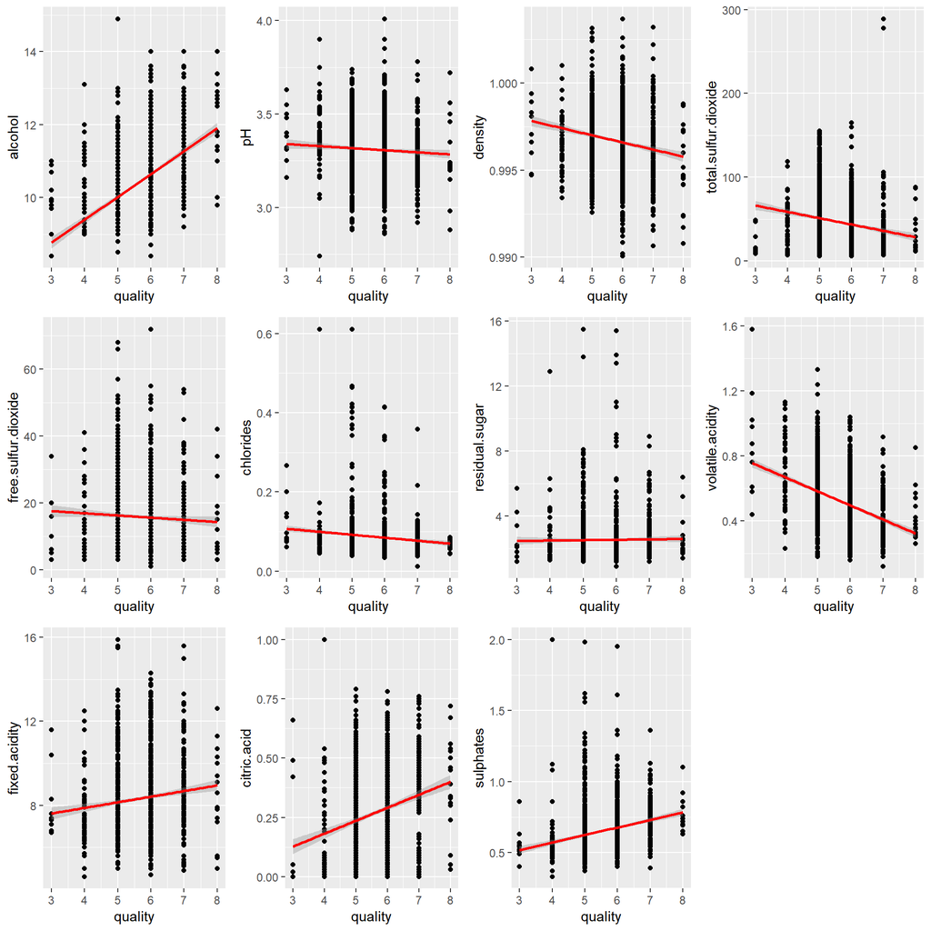

Observa-se que a qualidade vista de modo geral nao esta correlacionada fortemente com nenhum dos componentes quĂmicos do vinho tinto que compoem a amostra. Seria, entao, mais eficiente dividir a qualidade em tres classes: bom, medio e ruim, sendo ruim aquele vinho com nota quatro ou menos, bom o vinho com nota 7 ou superior e medio os demais.

```
##
##  ruim medio   bom
##    63  1319   217
```

Como visto dos coeficientes de correlacao extraidos acima, relativamente as correlacoes positivas, nenhuma supera o coeficiente de 0.5, de modo que nao se pode afirmar que exista uma forte correlacao entre a presenĂ§a de acido citrico, alcool, acidez fixada e sulfatos e a qualidade.

Antes de analisar a correlacao entre as variaveis cujos coeficientes de correlacao se mostram positivos em relaĂ§ao a qualidade, e de se investigar se a correlacao se mantem quando se extraem os coeficientes contemplam as categorias de qualidade baixo, medio e bom.

```
##
##  Pearson's product-moment correlation
##
## data:  quality and sulphates
## t = 0.3391, df = 61, p-value = 0.7357
## alternative hypothesis: true correlation is not equal to 0
## 95 percent confidence interval:
##  -0.2066094  0.2880455
## sample estimates:
##        cor
## 0.04337608
```

```
##
##  Pearson's product-moment correlation
##
## data:  quality and sulphates
## t = 5.9731, df = 1317, p-value = 2.992e-09
## alternative hypothesis: true correlation is not equal to 0
## 95 percent confidence interval:
##  0.1093882 0.2145003
## sample estimates:
##      cor
## 0.162405
```

```
##
##  Pearson's product-moment correlation
##
## data:  quality and sulphates
## t = 0.80324, df = 215, p-value = 0.4227
## alternative hypothesis: true correlation is not equal to 0
## 95 percent confidence interval:
##  -0.07906187  0.18652409
## sample estimates:
##        cor
## 0.05469851
```

```
##
##  Pearson's product-moment correlation
##
## data:  quality and alcohol
## t = 0.97924, df = 61, p-value = 0.3313
## alternative hypothesis: true correlation is not equal to 0
## 95 percent confidence interval:
##  -0.1272830  0.3610418
## sample estimates:
##       cor
## 0.1244053
```

```
##
##  Pearson's product-moment correlation
##
## data:  quality and alcohol
## t = 14.69, df = 1317, p-value < 2.2e-16
## alternative hypothesis: true correlation is not equal to 0
## 95 percent confidence interval:
##  0.3278896 0.4206801
## sample estimates:
##       cor
## 0.3752245
```

```
##
##  Pearson's product-moment correlation
##
## data:  quality and alcohol
## t = 2.592, df = 215, p-value = 0.0102
## alternative hypothesis: true correlation is not equal to 0
## 95 percent confidence interval:
##  0.0418609 0.3002971
## sample estimates:
##       cor
## 0.1740748
```

```
##
##  Pearson's product-moment correlation
##
## data:  quality and citric.acid
## t = 0.043708, df = 61, p-value = 0.9653
## alternative hypothesis: true correlation is not equal to 0
## 95 percent confidence interval:
##  -0.2425051  0.2530104
## sample estimates:
##         cor
## 0.005596182
```

```
##
##  Pearson's product-moment correlation
##
## data:  quality and citric.acid
## t = 2.9179, df = 1317, p-value = 0.003583
## alternative hypothesis: true correlation is not equal to 0
## 95 percent confidence interval:
##  0.02628424 0.13354412
## sample estimates:
##        cor
## 0.08014618
```

```
##
##  Pearson's product-moment correlation
##
## data:  quality and citric.acid
## t = 0.33229, df = 215, p-value = 0.74
## alternative hypothesis: true correlation is not equal to 0
## 95 percent confidence interval:
##  -0.1108629  0.1553716
## sample estimates:
##        cor
## 0.02265598
```

```
##
##  Pearson's product-moment correlation
##
## data:  quality and fixed.acidity
## t = -1.0217, df = 61, p-value = 0.311
## alternative hypothesis: true correlation is not equal to 0
## 95 percent confidence interval:
##  -0.3657205  0.1219763
## sample estimates:
##        cor
## -0.1297087
```

```
##
##  Pearson's product-moment correlation
##
## data:  quality and fixed.acidity
## t = 1.9424, df = 1317, p-value = 0.0523
## alternative hypothesis: true correlation is not equal to 0
## 95 percent confidence interval:
##  -0.0005297196  0.1071140939
## sample estimates:
##        cor
## 0.05344746
```

```
##
##  Pearson's product-moment correlation
##
## data:  quality and fixed.acidity
## t = -0.62012, df = 215, p-value = 0.5358
## alternative hypothesis: true correlation is not equal to 0
## 95 percent confidence interval:
##  -0.17445680  0.09144487
## sample estimates:
##         cor
## -0.04225416
```

Nota-se que o maior coeficiente de correlacao encontra-se na categoria dos vinhos de qualidade media.

# Trabalhando com duas variaveis

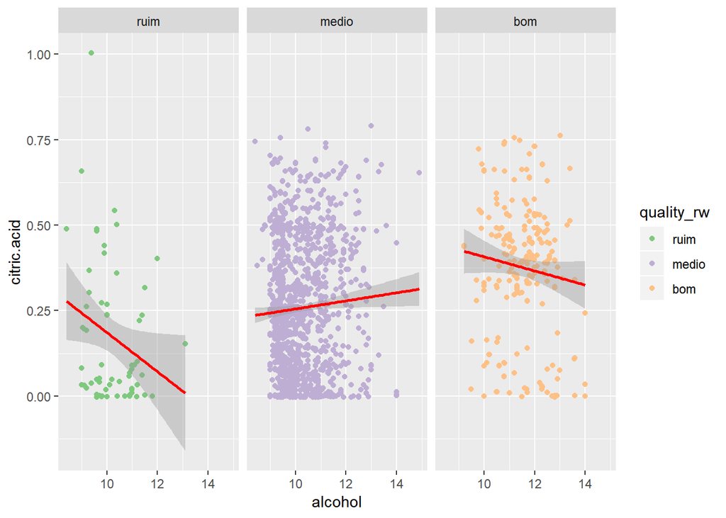

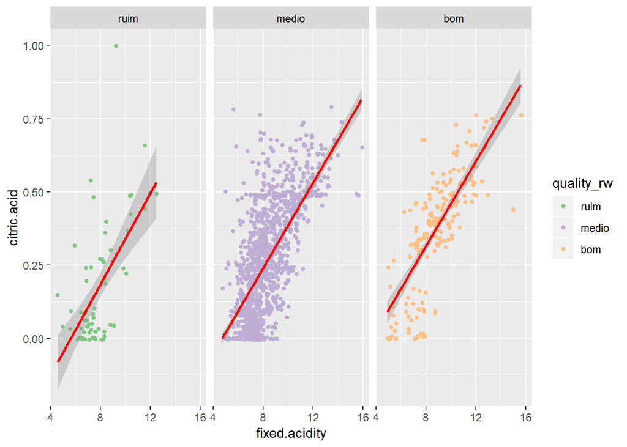

```r
ggplot(aes(x=fixed.acidity, y=citric.acid, color=quality_rw), data=redWines) +
  geom_point(position=position_jitter(), size=1.3,) +
  scale_color_brewer(type='qual') + geom_smooth(method = 'lm', color='red') +
  facet_wrap(~quality_rw)
```

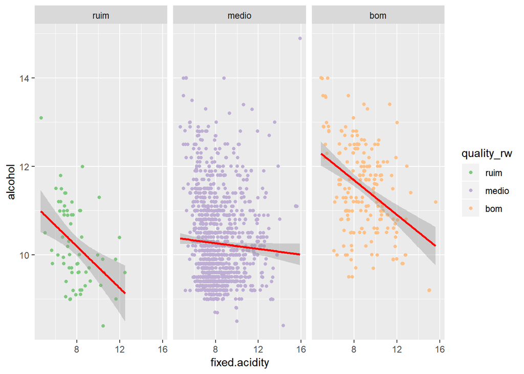

```r
ggplot(aes(x=fixed.acidity, y=alcohol, color=quality_rw), data=redWines) +
  geom_point(position=position_jitter(), size=1.3,) +
  scale_color_brewer(type='qual') + geom_smooth(method = 'lm', color='red') +
  facet_wrap(~quality_rw)
```

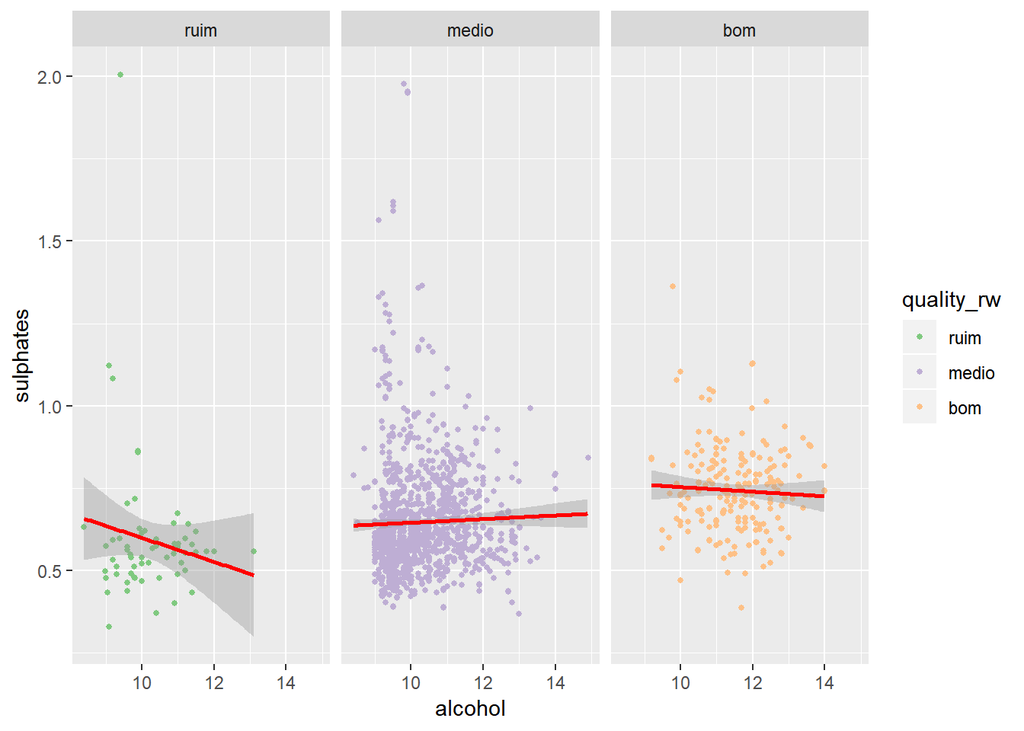

```r
ggplot(aes(x=alcohol, y=sulphates, color=quality_rw), data=redWines) +
  geom_point(position=position_jitter(), size=1.0,) +
  scale_color_brewer(type='qual') + geom_smooth(method = 'lm', color='red') +
  facet_wrap(~quality_rw)
```

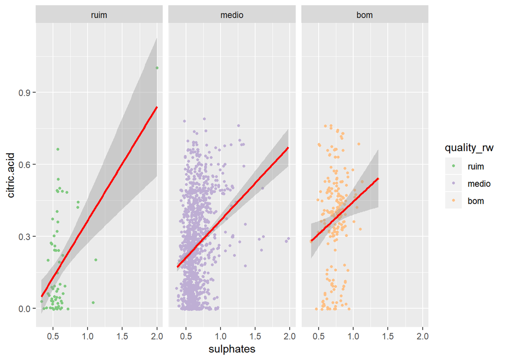

```r
ggplot(aes(x=sulphates, y=citric.acid, color=quality_rw), data=redWines) +
  geom_point(position=position_jitter(), size=1.0,) +
  scale_color_brewer(type='qual') + geom_smooth(method = 'lm', color='red') +
  facet_wrap(~quality_rw)
```

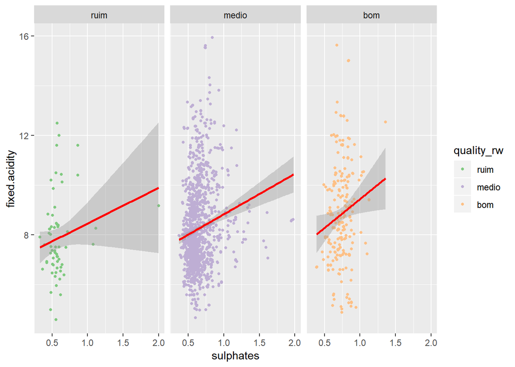

```r
ggplot(aes(x=sulphates, y=fixed.acidity, color=quality_rw), data=redWines) +
  geom_point(position=position_jitter(), size=1.0,) +
  scale_color_brewer(type='qual') + geom_smooth(method = 'lm', color='red') +
  facet_wrap(~quality_rw)
```

e interessante procurar correlacao entre as demais variaveis de modo a observar se uma outra substĂ˘ncia exerce alguma forma de influĂŞncia sobre a outra, especialmente as substĂ˘ncia que tem correlacao direta com o aumento da qualidade do vinho. Para atingir esta finalidade serĂĄ usada a funĂ§ao ggpairs().

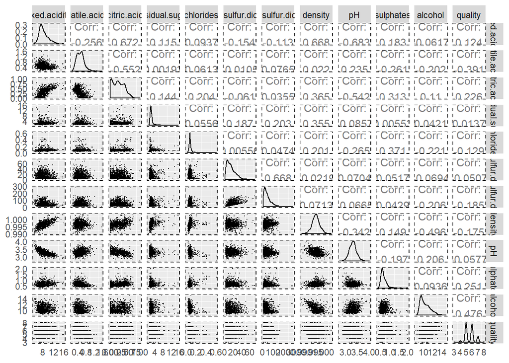

# graficos finais e SumĂĄrio

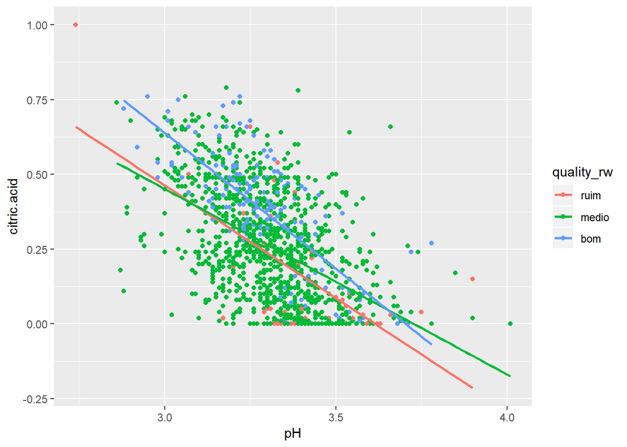

No grafico acima percebe-se claramente que para os vinhos de boa qualidade a presenĂ§a do pH e baixa enquanto a do acido citrico e alta.

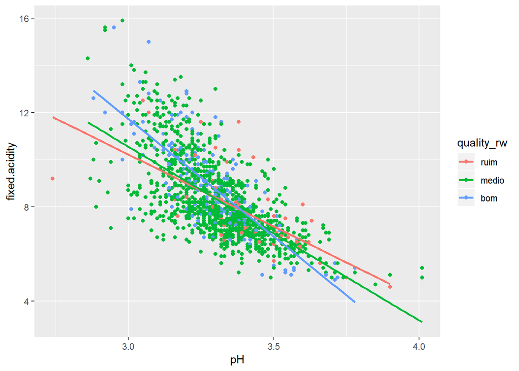

De igual forma ao que ocorre na relaĂ§ao pH versus acido citrico, para os vinhos bons quanto maior e a acidez fixada verificada nos vinhos de boa qualidade menor e o seu pH.

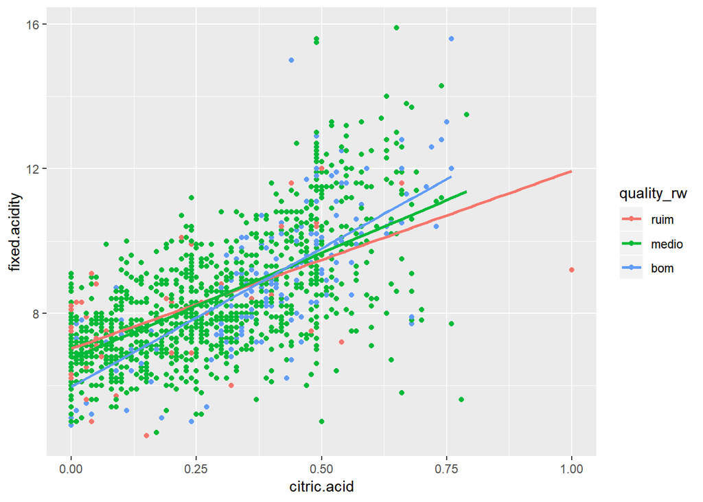

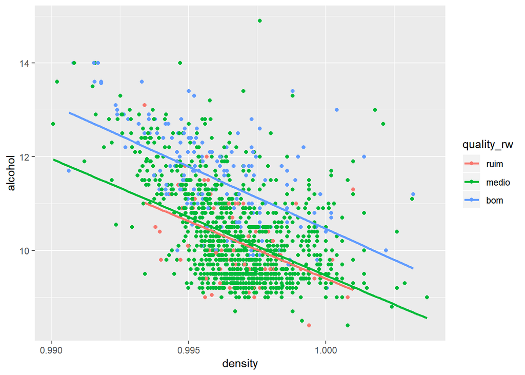

Como verificado anteriormente, a maior qualidade do vinho esta relacionada a maior quantidade de alcool em sua composicao, contudo, a densidade mais alta do liquido implica em menores quantidade de alcool, de modo que para se obter um vinho de boa qualidade a densidade nao pode ser alta. Contudo, os especialistas definem que um bom vinho deve ter um corpo medio (de acordo com os graus de densidade, da mais baixa para a mais alta = ralo, leve, medio, encorpado e pesado) para agradar ao paladar, o que significa que a densidade ideal deveria, ao que tudo indica, estar entre 0.9925 e 0.9975.

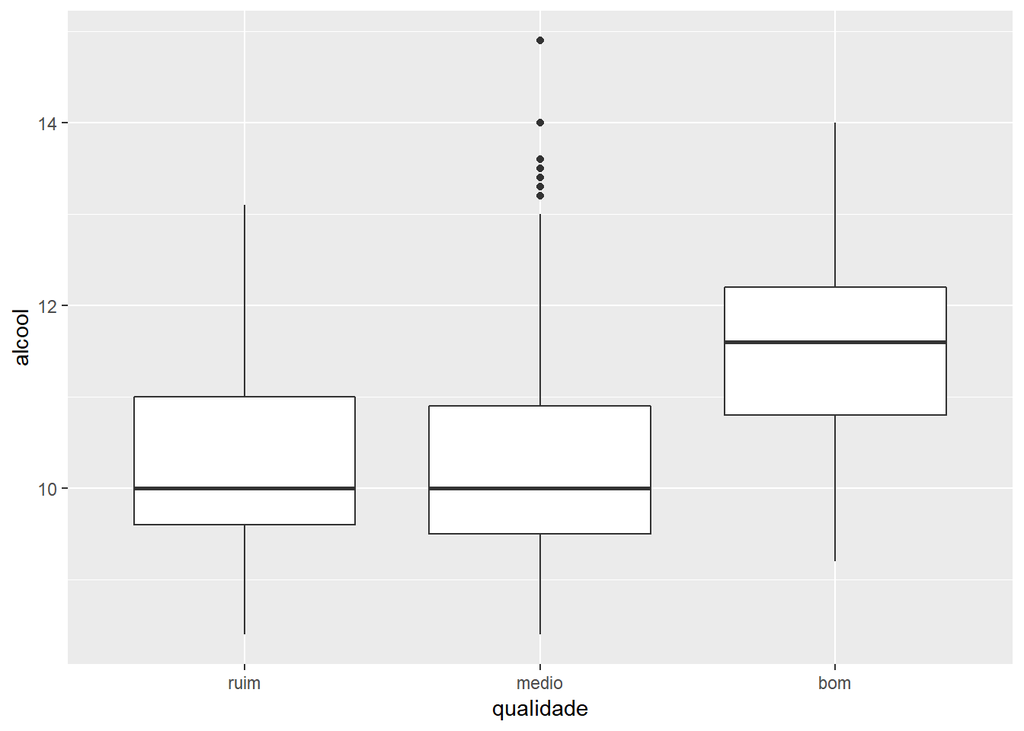

```r
qplot(x = quality_rw, y = alcohol, data = redWines, geom = 'boxplot', xlab= 'qualidade', ylab='alcool')
```

```r
by(redWines$alcohol, redWines$quality, summary)
```

```
## redWines$quality: 3
##    Min. 1st Qu.  Median    Mean 3rd Qu.    Max.
##   8.400   9.725   9.925   9.955  10.575  11.000
## --------------------------------------------------------
## redWines$quality: 4
##    Min. 1st Qu.  Median    Mean 3rd Qu.    Max.
##    9.00    9.60   10.00   10.27   11.00   13.10
## --------------------------------------------------------
## redWines$quality: 5
##    Min. 1st Qu.  Median    Mean 3rd Qu.    Max.
##     8.5     9.4     9.7     9.9    10.2    14.9
## --------------------------------------------------------
## redWines$quality: 6
##    Min. 1st Qu.  Median    Mean 3rd Qu.    Max.
##    8.40    9.80   10.50   10.63   11.30   14.00
## --------------------------------------------------------
## redWines$quality: 7
##    Min. 1st Qu.  Median    Mean 3rd Qu.    Max.
##    9.20   10.80   11.50   11.47   12.10   14.00
## --------------------------------------------------------
## redWines$quality: 8
##    Min. 1st Qu.  Median    Mean 3rd Qu.    Max.
##    9.80   11.32   12.15   12.09   12.88   14.00
```

Em conclusao, com base nas informacoes disponiveis nos rotulos de vinhos ao consumidor, que se constitui basicamente, na graduacao acoolica, uma boa compra tera alta chance de sucesso se for observada a graduacao acoolica igual ou acima de 12.15.

Fim da analise.

Obrigado!